# JSC370 2026 Final Project Report

Author

Yi Fan (Eric) Wang

Published

April 26, 2026

# 1. Introduction

Climate change is one of the major global challenges and is largely driven by carbon dioxide emissions from human activities. These emissions are not evenly distributed across countries: countries at different stages of economic development rely on different energy sources, follow different urbanization trends, and face different land-use pressures, all of which leave distinct imprints on their per-capita emissions. Understanding what drives these country-level differences is important for designing effective climate and energy policies.

This project examines the following research question:

**How have carbon dioxide emissions per capita evolved across countries from 1990 to 2023, and which economic, energy, and land-use factors explain and predict these differences?**

Based on the midterm analysis, this report hypothesizes that GDP per capita, urban population share, and renewable energy share are the dominant cross-country drivers of carbon dioxide emissions per capita, while fossil-fuel electricity share, and the calendar year play a smaller role.

The analysis uses data from 1990 to 2023 from the World Bank Open Data API, which provides a comprehensive set of development indicators covering economic, energy, and land-use factors. The dataset includes carbon dioxide emissions per capita, GDP per capita, renewable energy share, fossil-fuel electricity share, forest area as a percentage of land area, and urban population share, along with the year of observation as a temporal indicator.

This report extends the midterm analysis with more flexible methods that can capture more complex nonlinearities and interactions, and reports both predictive performance and variable importance to identify the dominant drivers of cross-country differences, as the midterm analysis found statistically significant evidence of non-linear relationships between carbon dioxide emissions per capita and its predictors.

# 2. Methods

## 2.1 Data Source and Acquisition

Data were obtained from the World Bank Open Data API for the period 1990–2023. The variables retained are carbon dioxide emissions per capita, GDP per capita, renewable energy share, fossil-fuel electricity share, forest area as a percentage of land area, and urban population share.

## 2.2 Data Cleaning and Wrangling

Rows were keyed by ISO3 country code and year to construct a country–year panel. Regional aggregates were removed. The table was reshaped to wide format, types and ranges were verified, and missing values were standardized as `NaN`. Missing observations were retained during EDA and dropped before regression analysis and modelling.

## 2.3 Exploratory Data Analysis

EDA used summary statistics, line plots, histograms, and scatter plots to examine temporal trends, distributional properties, and associations between emissions per capita and the explanatory variables.

## 2.4 Feature Engineering

Log transformations were applied to right-skewed variables (carbon dioxide emissions per capita and GDP per capita) to reduce the influence of extreme values. Percentage variables were kept on their original scale. The year was centered at 1990 to make the intercept and model coefficients more interpretable.

## 2.5 Regression Analysis

Before performing the regression analysis, rows with missing entries were dropped first, so all models were examined on a dataset with no missing entries.

Ordinary least squares (OLS) and generalized additive models (GAMs) from the midterm were used to capture linear and nonlinear patterns. The nonlinear evidence from the GAM motivated the more flexible machine learning models later on.

## 2.6 Modeling

Because the GAM showed statistically significant nonlinear relationships, two tree-based models were added. A pruned Decision Tree Regressor was used as an interpretable baseline. Then a XGBoost Regressor was used as a flexible gradient-boosted ensemble that can capture more complex nonlinearities and interactions.

### 2.6.1 Train / Validation / Test Split

The dataset is a country–year panel, so observations were split at the country level (grouped by `countryiso3code`) to prevent leakage of country-specific effects across sets. The split was approximately 70% / 15% / 15% by country, with the same fixed random seed across models for reproducibility and fair comparison.

Because countries (rather than years) are held out, test error measures generalization to **unseen countries given their full 1990–2023 predictor history** — directly matching the cross-country focus of the research question. It does **not** measure temporal forecasting (e.g., predicting 2024 from 1990–2023).

### 2.6.2 Decision Tree Model

A Decision Tree Regressor was fit as the interpretable baseline. The cost-complexity pruning parameter ($\alpha$) was tuned on the validation set, and the final pruned tree was refit on the combined training and validation sets and evaluated once on the test set.

### 2.6.4 Model Evaluation and Comparison

Models were compared on the same test set using regression model evaluation metrics, i.e. $R^2$, RMSE, and MAE. Variable importance was extracted from the final best model to identify the predictors contributing most to variation in emissions per capita.

# 3. Results

## 3.1 Data, EDA, and Regression Analysis Summary

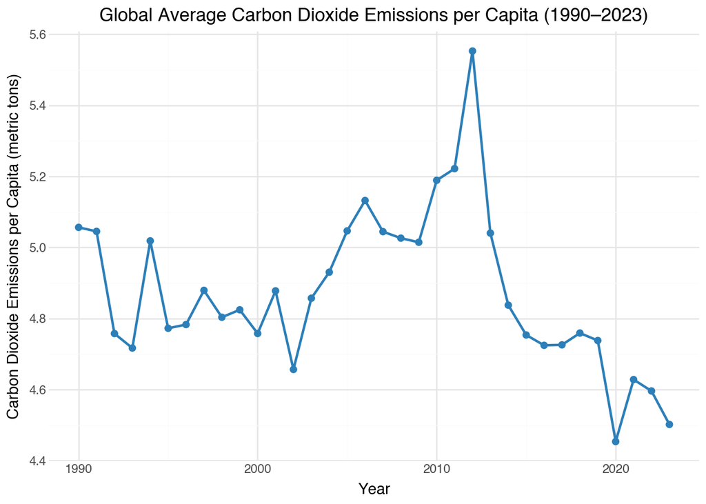

Figure 1: Global average CO2 emissions per capita over time (1990–2023)

GAM smooth-term summary

|  | Term | EDoF | p-value |
| --- | --- | --- | --- |
| 0 | Log GDP per Capita | 16.4797 | 0.0 |
| 1 | Fossil Electricity Share (% of total electrici... | 16.0733 | 0.0 |
| 2 | Renewable Energy Share (% of total final energ... | 15.8542 | 0.0 |
| 3 | Forest Area (% of total land area) | 15.4707 | 0.0 |
| 4 | Urban Population Share (% of total population) | 15.1863 | 0.0 |
| 5 | Year (centered at 1990) | 0.9779 | 0.0 |
| 6 | Intercept | 0.0000 | 0.0 |

The cleaned dataset covers 1990–2023 after regional aggregates were removed and variable ranges were verified. Missing values were moderate (most notably for fossil-fuel electricity share) and were handled by removing all the rows with missing entries before regression analysis and modelling. The dataset had 7378 rows before removal and 5499 rows after.

## 3.2 Modeling

Table 1: Country-grouped train / validation / test split

|  | Set | Rows | Countries |
| --- | --- | --- | --- |
| 0 | Train | 3826 | 136 |
| 1 | Validation | 833 | 30 |
| 2 | Test | 840 | 30 |

According to Table 1, the country-level data split placed roughly 70% of countries (136 out of 196) in the training set, 15% (30 out of 196) in the validation set, and 15% (30 out of 196) in the test set, with no country has observations appearing in more than one set. Therefore, test error measures generalization to unseen countries given their full 1990–2023 predictor history, which directly addresses the cross-country focus of the research question.

Table 2: Test-set performance comparison across models

|  | Model | Test R² | Test RMSE | Test MAE |
| --- | --- | --- | --- | --- |
| 0 | Decision Tree (pruned) | 0.7056 | 0.5581 | 0.3744 |
| 1 | XGBoost (tuned) | 0.7217 | 0.5426 | 0.3592 |

The pruned Decision Tree, after tuning `ccp_alpha` on the validation set and refitting on combined train and validation data, contained 18 leaves at depth 7 and reached a test-set $R^2$ of 0.706, RMSE of 0.558, and MAE of 0.374 on log carbon dioxide emissions per capita.

Table 3: Tuned XGBoost hyperparameters (5-fold GroupKFold random search + CV early stopping)

|  | Hyperparameter | Value |
| --- | --- | --- |
| 0 | max_depth | 6.0000 |
| 1 | learning_rate | 0.0300 |
| 2 | n_estimators | 154.0000 |
| 3 | reg_lambda | 0.1000 |
| 4 | reg_alpha | 10.0000 |
| 5 | subsample | 0.8000 |
| 6 | colsample_bytree | 1.0000 |
| 7 | min_child_weight | 5.0000 |
| 8 | gamma | 1.0000 |
| 9 | CV RMSE (random search) | 0.5979 |
| 10 | CV RMSE (early stop) | 0.5282 |

The tuned XGBoost used the hyperparameters in Table 3, where the hyperparameters were selected by 5-fold country-level randomized search on the training set (best CV RMSE = 0.5979) and refined by cross-validated early stopping on the combined train and validation sets, which selected 154 boosting rounds (CV RMSE = 0.5282). Refit on the combined sets, it reached a $R^2$ of 0.722, RMSE of 0.543, and MAE of 0.359 as the test performance. The untuned baseline XGBoost (200 trees, depth 5, learning rate 0.1) reached $R^2$ = 0.681, RMSE = 0.581, MAE = 0.388, confirming that tuned XGBoost outperformed the untuned baseline.

On the same test set (Table 2), the tuned XGBoost outperformed the pruned Decision Tree on every metric: $R^2$ rose from 0.706 to 0.722, and RMSE and MAE both fell from 0.558 to 0.543 log units and from 0.374 to 0.359 log units, respectively. The bettern performance across all three metrics indicates the tuned XGBoost Regressor captures more complex nonlinearities and predictor interactions that the single pruned tree could not. Therefore, the tuned XGBoost Regressor is the final best model.

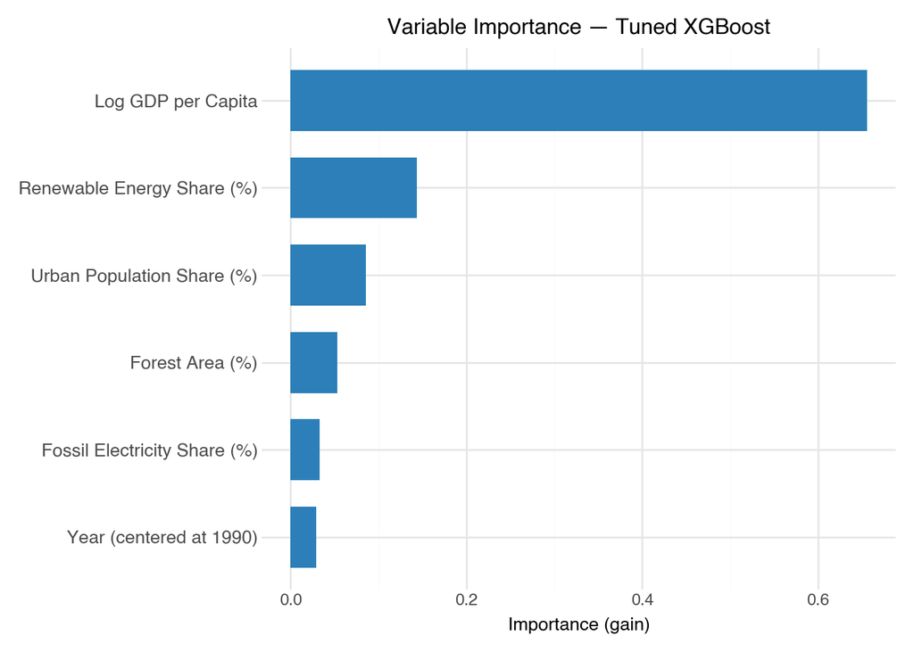

Figure 2: Gain-based feature importance for the tuned XGBoost (final model)

According to Figure 2, gain-based variable importance from the final model ranks log GDP per capita first by a clear margin, so log GDP per capita is the most important feature in determining the variation in carbon dioxide emissions per capita. Then renewable energy share and urban population share are the second and third most important features, followed by forest area, fossil electricity share, and the year. This ordering agrees with the hypothesis that economic development, energy sources, and urbanization are the key predictors of cross-country differences, while the calendar year adds little once those are known.

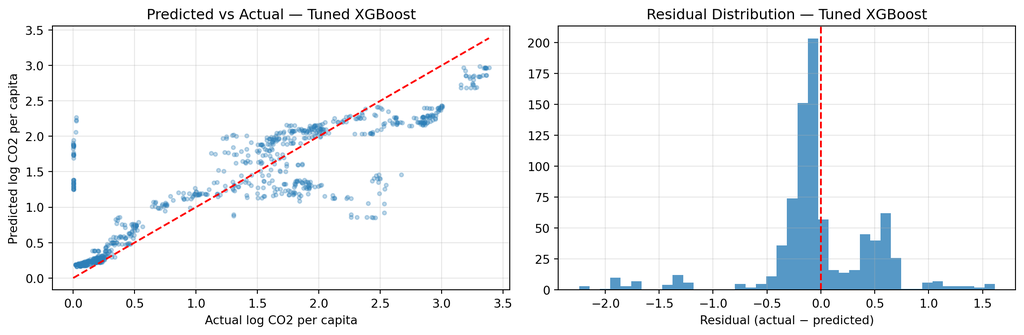

Figure 3: Predicted vs actual log carbon dioxide emissions per capita on the test set (tuned XGBoost)

# 4. Conclusions and Summary

## 4.1 Summary of Findings and Bigger Picture

Economic development remains the strongest predictor of carbon dioxide emissions per capita even after energy and land-use indicators are included. Growth aspirations and sustainable development goals in developing and less developed countries can only be reconciled through structural shifts (clean energy, more efficient technology, low carbon industry) rather than restraint on growth itself.

Renewable energy share was the second most important predictor, while fossil-fuel electricity share contributed far less. Renewable share likely includes fossil-fuel electricity information because it reflects the whole energy systemr ather than just electricity. In terms of policy implications, investing in renewables is the strongest single lever within this set of predictors.

## 4.3 Limitations

The country-level data split measures generalization to unseen countries given their full 1990–2023 predictor history, not temporal forecasting; predicting 2024 from 1990–2023 would require a forcasting princple split (strictly use 1990-2022 to trian and validate models, and use 2023 data for testing).

Dropping rows with missing entries before modelling removed a non-trivial share of country-years. If missingness is not uniform across countries, the modelled sample may skew toward those with stronger statistical reporting.

The predictor set is small and entirely national aggregated. Plausible predictors are not included, such as energy prices, weather,etc., which could account for some of the residual variance. The carbon dioxide emissions measure is also production-based, whereas trade-intensive countries look different under a consumption-based attribution.

Finally, all results are associational. Tree-based models do not produce causal estimates, and predictor importance reflects predictive contribution within the model rather than policy effectiveness.